# Segmentação

Guilherme Oliveria Casagrande

2023-09-19

### Refrigerantes - segmentação

Um estudo com algumas marcas de refrigerantes gostaria de identificar quais são os fatores que mais agradam o consumidor na hora da compra.

- X1. A marca Y tem um sabor refrescante (sabor)
- X2. Eu prefiro a marca Y porque tem menos calorias que outras bebidas (saúde)
- X3. A marca Y sacia minha sede imediatamente (sede)
- X4. Eu gosto do sabor suave da marca Y (sabor)
- X5. Eu prefiro tomar a marca Y após os exercícios e esportes porque ela me da energia (saúde)
- X6. A marca Y tem sabor único (sabor)
- X7. Eu prefiro tomar a marca Y quando eu estou com muita sede (sede)

```r
kable(head(dados1), caption = "Dados da pesquisa")
```

Dados da pesquisa

| X1 | X2 | X3 | X4 | X5 | X6 | X7 |
| --- | --- | --- | --- | --- | --- | --- |
| 4 | 3 | 5 | 3 | 3 | 3 | 4 |
| 4 | 5 | 6 | 4 | 5 | 4 | 5 |
| 7 | 6 | 6 | 6 | 7 | 6 | 5 |
| 7 | 4 | 4 | 6 | 4 | 7 | 5 |
| 4 | 5 | 7 | 3 | 4 | 3 | 7 |
| 7 | 5 | 5 | 7 | 6 | 6 | 5 |

Para segmentar, precisamos sempre realizar padronização!

```r
options(digits = 2)
kable(head(dados2), caption = "Dados padronizados")
```

Dados padronizados

| X1 | X2 | X3 | X4 | X5 | X6 | X7 |
| --- | --- | --- | --- | --- | --- | --- |
| -0.85 | -0.95 | 0.23 | -1.32 | -0.79 | -1.68 | -0.46 |
| -0.85 | 0.35 | 0.88 | -0.64 | 0.36 | -0.91 | 0.23 |
| 1.27 | 1.00 | 0.88 | 0.70 | 1.51 | 0.63 | 0.23 |
| 1.27 | -0.30 | -0.42 | 0.70 | -0.22 | 1.40 | 0.23 |
| -0.85 | 0.35 | 1.53 | -1.32 | -0.22 | -1.68 | 1.63 |
| 1.27 | 0.35 | 0.23 | 1.37 | 0.94 | 0.63 | 0.23 |

O próximo passo é encontrar quem é parecido com quem… E plotar em um grafico chamado dendrograma.

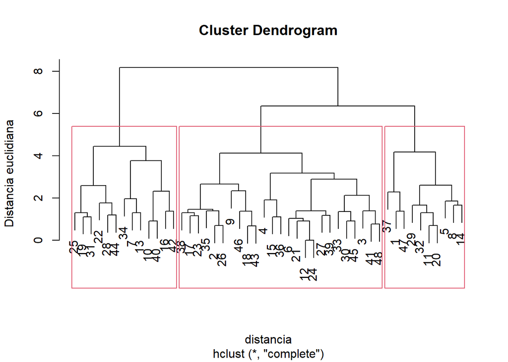

```r
distancia = dist(dados2)

h = hclust(distancia, method = "complete")

plot(h, ylab = "Distancia euclidiana")
rect.hclust(h, k = 3)
```

Como saber quais as marcas avaliadas?

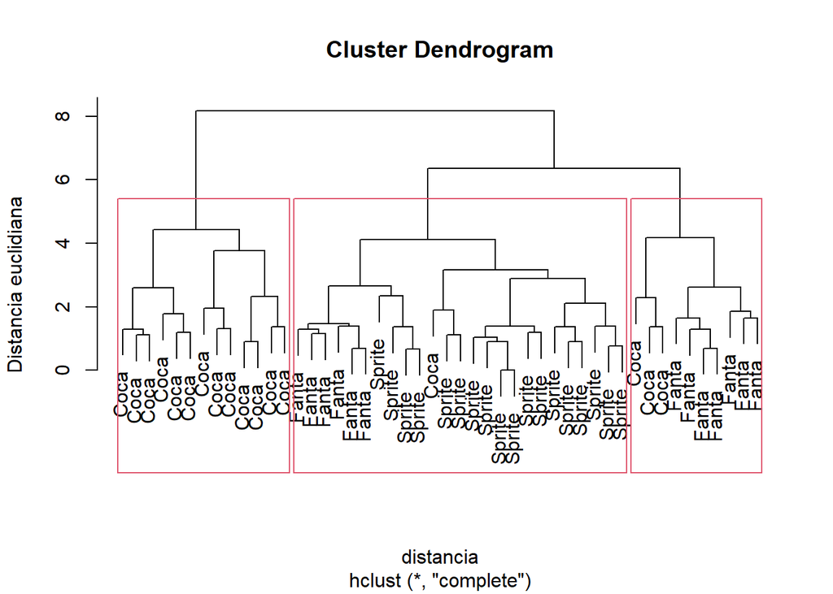

```r
marcas = dados$MARCA
plot(h, labels = marcas, ylab = "Distancia euclidiana")
rect.hclust(h, k = 3)
```

Existem outras maneiras de se analisar os segmentos. Uma delas é via o mapa de calor.

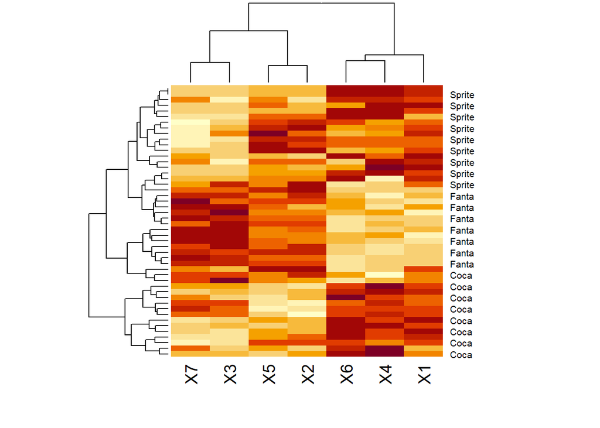

```r
heatmap(dados2, labRow = marcas)
```

- X7 e X3 são variaveis parecidas (sede);
- X5 e X2 (saúde);
- X1, X4 e X6 (sabor).

Pelas manchas no mapa de calor, podemos perceber qual o perfil de cada cluster.

Cluster Sprite: valoriza sabor e saúde; Cluster Fanta: valoriza sede e saúde; Cluster Coca: valoriza sabor.

Para fazer com que a segmentação seja incorporada à base de dados, é preciso utilizar o método das k-médias. Esse método de segmentação não é hierarquico e necessita da quantidade de grupos.

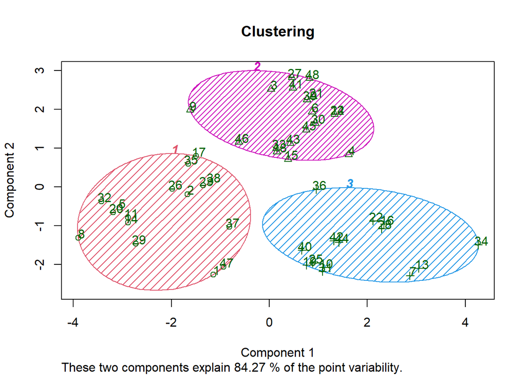

```r
grupos = kmeans(dados2, 3) # quantos clusters?

dados$cluster = grupos$cluster # associa o numero do cluster aos dados

# library(cluster)
clusplot(dados2, grupos$cluster, color=TRUE, shade=TRUE, labels=2, lines=0, main = "Clustering")
```

```r
write.csv2(dados, "clusters.csv", row.names = FALSE) # gera o csv
```

Depois que conhecemos os segmentos, podemos fazer uma analise dos perfis dos grupos.

```r
tabela1 = table(dados$MARCA, dados$cluster)
kable(tabela1, caption = "Predominancia de marca por grupo")
```

Predominancia de marca por grupo

|  | 1 | 2 | 3 |
| --- | --- | --- | --- |
| Coca | 3 | 1 | 13 |
| Fanta | 13 | 0 | 0 |
| Sprite | 0 | 17 | 1 |

```r
tabela2 = dados %>% mutate(sabor = (X1 + X4 + X6)/3,
                           sede = (X3 + X7)/2,
                           saude = (X2 + X5)/2) %>%
        group_by(cluster) %>%
        summarise(sabor = round(mean(sabor),2),
                  sede = round(mean(sede),2),
                  saude = round(mean(saude),2),
                  n = n())
kable(tabela2, caption = "Analise dos perfis dos grupos")
```

Analise dos perfis dos grupos

| cluster | sabor | sede | saude | n |
| --- | --- | --- | --- | --- |
| 1 | 3.6 | 5.8 | 4.7 | 16 |
| 2 | 6.2 | 4.9 | 5.8 | 18 |
| 3 | 5.4 | 3.1 | 2.4 | 14 |

As analises acima precisam coincidir com as analises que foram feitas no mapa de calor.